# Conda

Raoul Bonnal and Lorenzo Drufuca

04/04/2023

# Conda

[figure not shown]

> Package, dependency and environment management for any language—Python, R, Ruby, Lua, Scala, Java, JavaScript, C/ C++, FORTRAN

## Conda

Conda is an open-source package management system and environment management system that runs on Windows, macOS, and Linux.

1. Conda quickly installs, runs, and updates **packages** and their dependencies.
2. Conda easily creates, saves, loads, and switches between **environments** on your local computer.

> **PACKAGES** ???

> **ENVIROMENTS** ???

# Packages

## Packages

[figure not shown]

I am alone in an empty room and I want to paint “L’Urlo” by Munch.

What i need?

- Brushes
- Temperas
- Canvas

If you think the room where you are as the **computer** you are using, then the **Brushes**, **Temperas** and **Canvas** are the informatics tools you need to perform an operation. These informatics tools are distributed as **packages**.

> Basically a **package** refers to a compressed file archive containing all of the files that come with a particular tool/application.

Thinking again to the painting, because you need some objects to make it, you could say it **depends** by those objects.

In other words the painting has some **dependencies**.

In the same way every application that you need to use in your computers has some **dependencies** and you need to install them before running the application.

Moreover, every **dependencies** would in turn has other dependencies and so on…

We satisfy **dependencies** by installing **packages**.

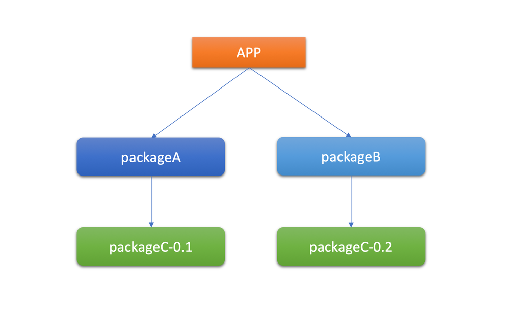

# Environments

## Environments

In the same way the **packages** are represented by the tools needed to do the **painting**, the “room” in which they are collected, in your computer is called **enviroment**.

> Simplifying the concept, an **environment** is the collection of all the informatics tools/application/librarires/variables that you, or other software, could access on your computer.

Now imagine that you want to build a car.

[figure not shown]

As seen before you will need new tools available in your room, such as:

1. screwdrivers
2. screws
3. wrenches

In other words to use a new software you often need to install new packages on your computer.

In your room you have **6 objects** and it is easy to find exactly what you need.

After some times you are able to do all these things:

[figure not shown]

- How many tools are inside the room?
- Is still easy to find and manage the tools you need?

In the same way when you install a lot of software in your computer a huge amount of packages are installed.

As a room full of abjects, the increasing complexity could create issues on your system.

Any solutions for this?

Imagine to split out your room in many small rooms, and to put inside each of them only the tools you need to make a specific operation or to run a specific software.

In this way it will be simplier to manage and use the tools you need.

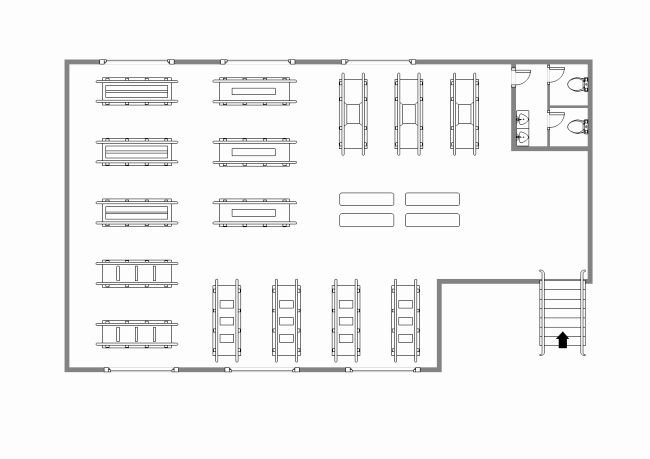

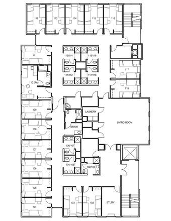

On your computer the multiple **rooms** are called **virtual environments**.

> A virtual environment is a tool that helps to keep dependencies required by different projects separate by creating isolated spaces for them that contain per-project dependencies for them.